# Ecologia Numérica - Alunos 2023

Tiago A. Marques

September 13, 2023

# Introdução

Este documento é um exemplo de um documento de R Markdown. O R Markdown pode ser usado para criar documentos dinâmicos, que podem ser exportados como HTML (default) mas ainda como word ou pdf. Most probably you are reading this as an html from the git reposityry hosted at:

https://github.com/TiagoAMarques/wordcloudEN2023

Isto pode ser util quando estamos a realizar uma análise sobre um conjunto de dados que (eventualmente) possa sofrer alterações ao longo do tempo (e.g. um novo aluno inscreve-se, um novo animal é capturado, um novo local é visitado, etc).

Neste caso, vamos criar uma wordcloud com os nomes dos alunos de EN em 2023/2024

Para analisar este conjunto de dados vamos necessitar de utilizar o seguinte conjunto de packages extra:

```r
library("tm")
library("SnowballC")
library("wordcloud")
library("RColorBrewer")
```

Tipicamente os comandos acima poderiam estar escondidos, usando o argumento `echo=FALSE` no respectivo code chunk. Por default `echo=TRUE`, ou seja, todo o código fica visível no output (e.g. html, word, pdf) gerado.

# Os dados

Os dados analisados aqui foram obtidos exportando um .xls do sistema Fenix a 13 09 2023. O nome do ficheiro é “students_66517_Ecologia_Numerica.2023-09-13_13-12-34_375_fromFENIX.xlsx”. Por razões de RGPD este ficheiro não deve ser partilhado com os alunos.

Aqui são partilhados com os alunos os nomes, num ficheiro que contem em cada linha um nome (uma palavra), aleatoriamente seleccionado de todos os nomes dos alunos para anonimizar os nomes completos. Essa informação está no documento “nomesAnonimos.txt”, criado no documento alunos2023.Rmd, a que os alunos não tem acesso.

# Text analysis com base nos nomes

Existe um grande campo da estatística de text analysis, mas aqui vamos apenas construir uma wordcloud.

```r
nomes=VCorpus(DirSource(directory="text4tmA",encoding = "UTF-8"),
readerControl=list(language = "lat"))
```

Removemos stop words, como “dos”“,”da” e “de”

```r
#retiras o "dos"" e o "do" e o "de"
nomes <- tm_map(nomes, removeWords, c("dos","de","da","do"))
```

organizamos os dados

```r
dtm <- TermDocumentMatrix(nomes)
m <- as.matrix(dtm)
v <- sort(rowSums(m),decreasing=TRUE)
d <- data.frame(word = names(v),freq=v)
```

Vemos quais os nomes mais frequentes

```r
head(d, 25)
```

|  | word | freq |
| --- | --- | --- |
| silva | silva | 21 |
| santos | santos | 19 |
| pereira | pereira | 13 |
| miguel | miguel | 10 |
| sofia | sofia | 10 |
| alexandra | alexandra | 9 |
| carolina | carolina | 8 |
| martins | martins | 8 |
| maria | maria | 7 |
| alexandre | alexandre | 6 |

[output cut: 15 more lines]

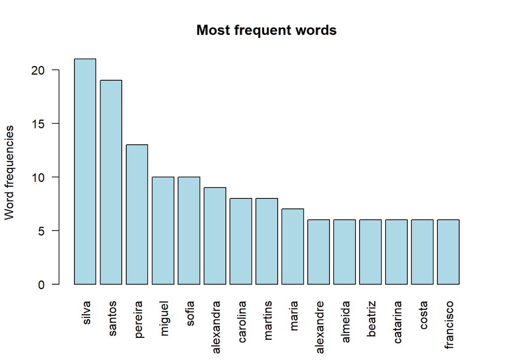

```r
barplot(d[1:15,]$freq, las = 2, names.arg = d[1:15,]$word,
        col ="lightblue", main ="Most frequent words",
        ylab = "Word frequencies")
```

Temos Santos Silva em grande (não fazer piadas politicas, não é sobe o Augusto…).

Vamos finalmente criar uma bonita cloud tag dos nomes dos alunos de Ecologia Numérica em 2023/2024, que costumo usar nas aulas para depois de “quem sou eu” lhes mostrar “quem são eles”. Ou será que eles são só nomes? Cabe-lhes a eles mostrar que não!

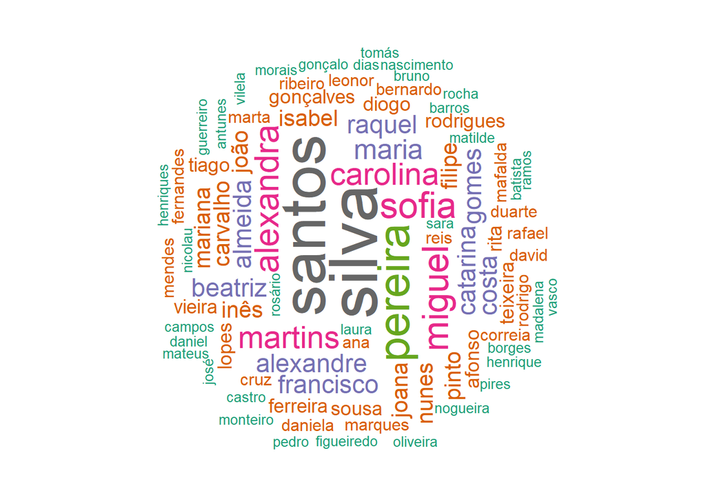

```r
#create tag cloud
#replace with your student number
#for your unique experience!
# as this is MY student number
student.number<-19549
set.seed(student.number)
wordcloud(words = d$word, freq = d$freq, min.freq = 2,
          max.words=200, random.order=FALSE, rot.per=0.35,
          colors=brewer.pal(8, "Dark2"))
```

And now, up to you to test other stuff around text analysis!

A nice thing to do. Add manually pretend new 120 students, with the names Tiago, Susana, Sofia, Hugo, say repeated 30 times each name.

In other words, just run the lines of code in the next chunk, which are currently not evaluated since I set the option `eval=FALSE`. This creates a new file that is added to the folder “text4tmA”, and that will mean that next time you compile this document, there are more names in the folder where the routine looks for the names, so these are added, and the word cloud updated accordingly.

```r
fake.names<-rep(c("Tiago","Susana","Sofia","Hugo"),each=30)
write.table(fake.names,file="text4tmA/FakeNamesArTheBestNames.txt",
col.names=FALSE,quote=FALSE,row.names = FALSE)
```

Re-compile the document, and check how the teachers names have now contaminated it all ;)

But think how handy this can be in the case where you have an analysis that you did, but then collected new data. Instead of redoing all the work, you just have to recompile a dynamic report. If you have done that, send me the screenshot :) - it could be worth bonus points for your assessment if you replace my `student number` 19549 by your student number, in the code above.

Do you know what the function `set.seed()` is doing in the above code? Can you find out? Google is your friend ;)